# Democrats vs Republicans

In this study, I focus on U.S. Presidential inauguration speeches of the recent 8 presidents. Here I conduct a brief comparison of speeches by the parties to which presidents stand for.

### List of Presidents of the United States from 1969 to 2018

| id | President | Presidency | Party |
| --- | --- | --- | --- |
| 1 | Richard Nixon | 1969-1974 | Republican |
| 2 | Jimmy Carter | 1977-1981 | Democratic |
| 3 | Ronald Reagan | 1981-1989 | Republican |
| 4 | George Bush | 1989-1993 | Republican |
| 5 | William J. Clinton | 1993-2001 | Democratic |
| 6 | George W. Bush | 2001-2009 | Republican |
| 7 | Barack Obama | 2009-2017 | Democratic |
| 8 | Donald J. Trump | 2017-Incumbent | Republican |

### Length of the Inaugural Addresses

In the recent 40 years, the average number of words used by each president fluctuate between 1200 to 2500, and it seems like the presidents of the Democratic Party delivered slightly shorter speeches.

Presidents known to have good public-speaking techniques, such as Ronald Reagan and Barack Obama, have long addresses.

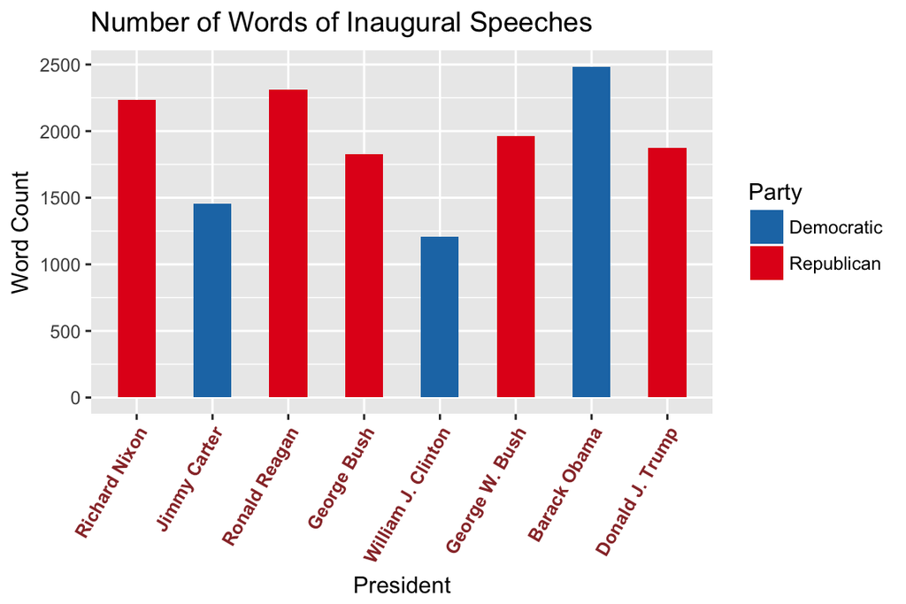

[output not shown]

### The most frequently used 100 words for presidents of the Republicans Party

In the text cleaning process, besides the usual procedure, I manually removed some uninformative words like will, can, and let and replaced some synonyms.

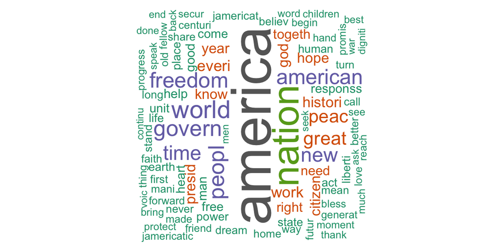

### The most frequently used 100 words for presidents of the Democratic Party

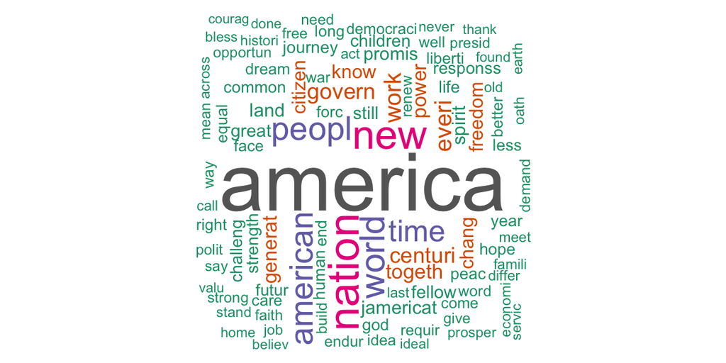

# Top 20 Shared Words Used by Presidents of Two Parties

```
[1] 5.1 4.1 2.1 2.1
```

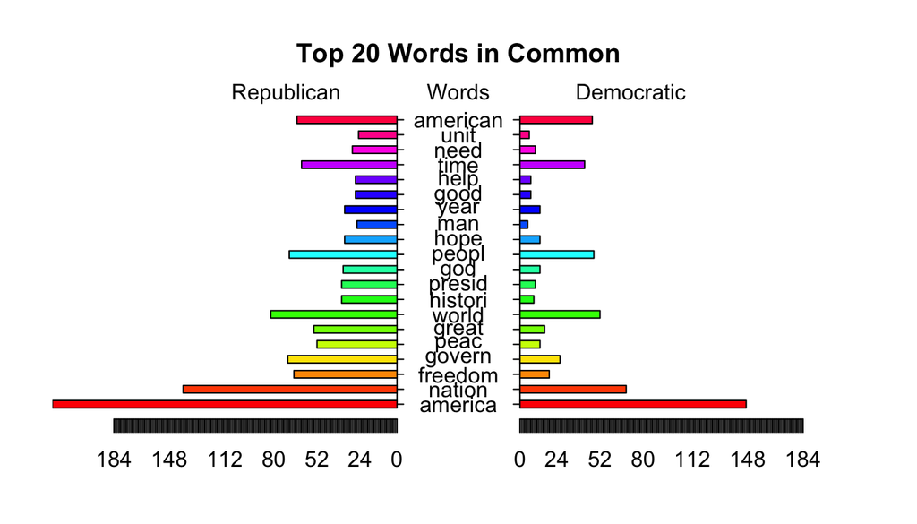

The most frequently words shared are America, people, world, nation, government, etc. This is expected because inaugural addresses are used to present presidents’ visions and goals for the country, their promises to the people, and the missions for the government. Words like peace, freedom are long-term goals that could not be emphasized enough. When the presidents look back in history, it seems like they care about aid they received, wins, threatens to lives of the people, and rebuilding the country.

```
  almost      aid  million      pay      win     back     step threaten     weve  rebuild
    0.82     0.82     0.76     0.76     0.76     0.75     0.71     0.69     0.69     0.66
```

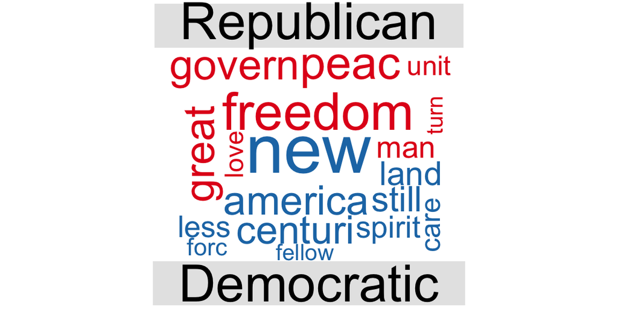

Code from https://s3.amazonaws.com/assets.datacamp.com/production/course_935/ch2_pdf_slides.pdf

| Party | 1 | 2 | 3 | 4 | 5 | 6 | 7 | 8 | 9 | 10 | 11 | 12 | 13 | 14 | 15 | 16 | 17 | 18 | 19 | 20 | 21 | 22 | 23 | 24 | 25 | 26 |
| --- | --- | --- | --- | --- | --- | --- | --- | --- | --- | --- | --- | --- | --- | --- | --- | --- | --- | --- | --- | --- | --- | --- | --- | --- | --- | --- |
| Republican | histori | presid | need | good | help | free | man | heart | unit | place | act | earth | state | go | believ | stand | call | faith | first | home | mean | never | share | forward | mani | turn |
| Democratic | generat | chang | land | spirit | promis | fellow | still | children | challeng | journey | strength | common | futur | less | care | end | face | forc | democraci | endur | equal | idea | renew | requir | war | well |

We took a look at the words, it seems like presidents from parties differ greatly in their philosophies.

Presidents from the Democratic party talks more about equality & health care, children land issues, whereas presidents from the Republican party talks more about freedom, housing policies, state, and union.

#### Closer look at some ambiguous words and its syntax

For presidents of the Republicanr Party, the word “never” which is associated with negative sentiments is related to immigration.

For presidents of the Democratic Party, the word “future” is associated with dignity and school.

| 1 | 2 | 3 | 4 | 5 | 6 | 7 | 8 | 9 | 10 |
| --- | --- | --- | --- | --- | --- | --- | --- | --- | --- |
| mani | follow | demand | along | anyth | arriv | convict | exampl | immigr | knowledg |

| 1 | 2 | 3 | 4 | 5 | 6 | 7 | 8 | 9 | 10 |
| --- | --- | --- | --- | --- | --- | --- | --- | --- | --- |
| year | life | digniti | school | effort | guid | secur | creat | free | journey |

### Democrats vs Republicans: Topics of Inaugural Addresses

We study how often presidents address 7 topics: Economy , Equality, Misc, Legislation, Government, Reform,Freedom. And it seems like there is only subtle difference between parties. Finally we look at a correlation plot of the topics Inaugural Addresses , and it’s obvious that topics change over years, and the presidents in the recent years deliever similar topics. Topics of President Donald Trump is very different from the other presidents.

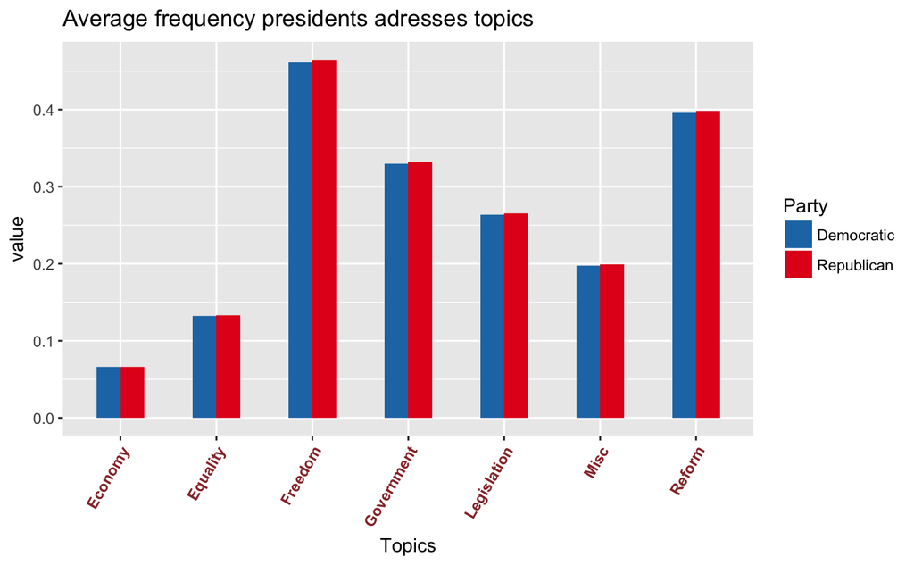

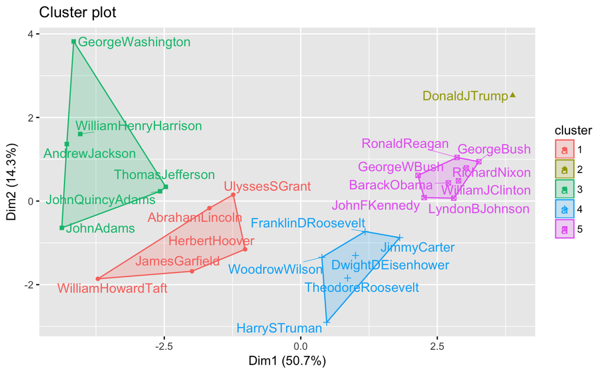